# Pertemuan 3 - Regresi dengan Peubah Lag

Naa’ila Nur Musyaffa

# Latihan 1

## Data

```r
data <- data.frame(
  Periode = 1:20,
  Y = c(3.63, 4.20, 3.33, 4.54, 2.89,
        4.87, 4.90, 5.29, 6.18, 7.20,
        7.25, 6.09, 6.80, 8.65, 8.43,
        8.29, 7.18, 7.90, 8.45, 8.23),
  X = c(0.97, 0.95, 0.99, 0.91, 0.98,
        0.90, 0.89, 0.86, 0.85, 0.82,
        0.79, 0.83, 0.81, 0.77, 0.76,
        0.80, 0.83, 0.79, 0.76, 0.78)
)

data
```

```
##    Periode    Y    X
## 1        1 3.63 0.97
## 2        2 4.20 0.95
## 3        3 3.33 0.99
## 4        4 4.54 0.91
## 5        5 2.89 0.98
## 6        6 4.87 0.90
## 7        7 4.90 0.89
## 8        8 5.29 0.86
## 9        9 6.18 0.85
## 10      10 7.20 0.82
## 11      11 7.25 0.79
## 12      12 6.09 0.83
## 13      13 6.80 0.81
## 14      14 8.65 0.77
## 15      15 8.43 0.76
## 16      16 8.29 0.80
## 17      17 7.18 0.83
## 18      18 7.90 0.79
## 19      19 8.45 0.76
## 20      20 8.23 0.78
```

# Membuat Variabel Lag

```r
data$X1 <- c(NA, data$X[1:19])
data$X2 <- c(NA, NA, data$X[1:18])
data$X3 <- c(NA, NA, NA, data$X[1:17])
data$X4 <- c(NA, NA, NA, NA, data$X[1:16])
```

# Model distributed lag

```r
# Lag 0
model0 <- lm(Y ~ X, data = data)

# Lag 1
model1 <- lm(Y ~ X + X1, data = data)

# Lag 2
model2 <- lm(Y ~ X + X1 + X2, data = data)

# Lag 3
model3 <- lm(Y ~ X + X1 + X2 + X3, data = data)

# Lag 4
model4 <- lm(Y ~ X + X1 + X2 + X3 + X4, data = data)
```

# Membandingkan Model Terbaik

```r
hasil <- data.frame(
  Model = c("Lag 0", "Lag 1", "Lag 2", "Lag 3", "Lag 4"),
  AIC = c(AIC(model0), AIC(model1), AIC(model2),
          AIC(model3), AIC(model4)),
  BIC = c(BIC(model0), BIC(model1), BIC(model2),
          BIC(model3), BIC(model4))
)

hasil
```

```
##   Model      AIC      BIC
## 1 Lag 0 26.77133 29.75852
## 2 Lag 1 26.92349 30.70125
## 3 Lag 2 25.35338 29.80524
## 4 Lag 3 22.34354 27.34282
## 5 Lag 4 24.58541 29.99353
```

# Model dengan AIC dan BIC terkecil

```r
hasil[which.min(hasil$BIC), ]
```

```
##   Model      AIC      BIC
## 4 Lag 3 22.34354 27.34282
```

Berdasarkan perbandingan nilai AIC dan BIC dari beberapa model Distributed Lag, diperoleh bahwa model dengan lag 3 memiliki nilai AIC dan BIC paling kecil. Oleh karena itu, model Distributed Lag dengan lag 3 dipilih sebagai model terbaik, karena memberikan keseimbangan yang paling baik antara kesesuaian model dan kompleksitas model.

# Model terbaik

```r
model_terbaik <- list(
  model0, model1, model2, model3, model4
)[[which.min(hasil$BIC)]]

summary(model_terbaik)
```

```
##
## Call:
## lm(formula = Y ~ X + X1 + X2 + X3, data = data)
##
## Residuals:
##      Min       1Q   Median       3Q      Max
## -0.66726 -0.12861  0.04445  0.20095  0.65215
##
## Coefficients:
##             Estimate Std. Error t value Pr(>|t|)
## (Intercept)  29.3254     1.3483  21.751 5.23e-11 ***
## X           -22.6847     3.1447  -7.214 1.07e-05 ***
## X1            0.6568     2.9252   0.225    0.826
## X2           -1.6947     2.9316  -0.578    0.574
## X3           -3.3754     2.7215  -1.240    0.239
## ---
## Signif. codes:  0 '***' 0.001 '**' 0.01 '*' 0.05 '.' 0.1 ' ' 1
##
## Residual standard error: 0.3904 on 12 degrees of freedom
##   (3 observations deleted due to missingness)
## Multiple R-squared:  0.9596, Adjusted R-squared:  0.9462
## F-statistic: 71.35 on 4 and 12 DF,  p-value: 2.917e-08
```

# Koefisien model

```r
coef(model_terbaik)
```

```
## (Intercept)           X          X1          X2          X3
##  29.3254410 -22.6846649   0.6568221  -1.6947239  -3.3754367
```

Berdasarkan hasil estimasi, diperoleh koefisien intercept sebesar 29,3254, X sebesar -22,6847, X1 sebesar 0,6568, X2 sebesar -1,6947, dan X3 sebesar -3,3754. Koefisien X, X2, dan X3 bernilai negatif yang menunjukkan bahwa kenaikan harga pada periode tersebut cenderung menurunkan pangsa pasar, sedangkan X1 bernilai positif yang menunjukkan hubungan searah dengan pangsa pasar. Koefisien terbesar secara absolut terdapat pada X, sehingga harga pada periode sekarang memiliki pengaruh paling besar terhadap pangsa pasar dalam model.

# R-squared dan MSE

```r
summary(model_terbaik)$r.squared
```

```
## [1] 0.9596484
```

```r
summary(model_terbaik)$adj.r.squared
```

```
## [1] 0.9461978
```

```r
mean(residuals(model_terbaik)^2)
```

```
## [1] 0.1075893
```

Nilai R-squared sebesar 0,9596 atau 95,96%, artinya sebesar 95,96% variasi pangsa pasar dapat dijelaskan oleh harga pada periode sekarang hingga tiga periode sebelumnya. Sementara itu, sebesar 4,04% variasi pangsa pasar dijelaskan oleh faktor lain yang tidak terdapat dalam model. Nilai Adjusted R-squared sebesar 0,9462 atau 94,62% menunjukkan bahwa setelah memperhitungkan jumlah variabel dalam model, kemampuan model dalam menjelaskan variasi pangsa pasar masih tergolong tinggi.

# Nilai prediksi dan residual

```r
fitted(model_terbaik)
```

```
##        4        5        6        7        8        9       10       11
## 4.448489 2.807736 4.669047 4.994752 5.568021 6.062146 6.820713 7.599759
##       12       13       14       15       16       17       18       19
## 6.757264 7.389335 8.317059 8.416510 7.637853 7.135550 8.028607 8.497015
##       20
## 7.990143
```

```r
residuals(model_terbaik)
```

```
##           4           5           6           7           8           9
##  0.09151140  0.08226393  0.20095275 -0.09475239 -0.27802146  0.11785438
##          10          11          12          13          14          15
##  0.37928658 -0.34975905 -0.66726387 -0.58933487  0.33294083  0.01349006
##          16          17          18          19          20
##  0.65214718  0.04444954 -0.12860713 -0.04701501  0.23985710
```

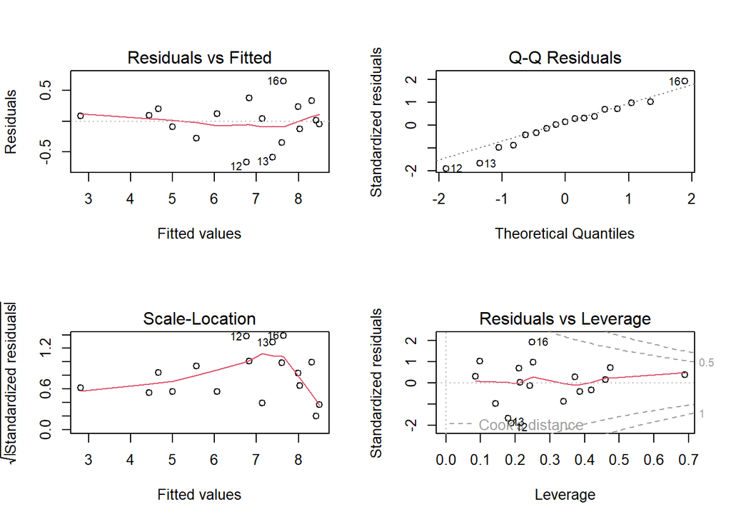

```r
par(mfrow = c(2, 2))
plot(model_terbaik)
```

```r
par(mfrow = c(1, 1))
```

# Uji normalitas residual

```r
shapiro.test(residuals(model_terbaik))
```

```
##
##  Shapiro-Wilk normality test
##
## data:  residuals(model_terbaik)
## W = 0.97461, p-value = 0.8929
```

# Model Terbaik

```r
formula(model_terbaik)
```

```
## Y ~ X + X1 + X2 + X3
```

Berdasarkan uji Shapiro-Wilk, diperoleh nilai W = 0,97461 dengan p-value = 0,8929. Karena p-value > 0,05, maka H₀ tidak ditolak, sehingga dapat disimpulkan bahwa residual model berdistribusi normal. Jadi, asumsi normalitas residual pada model terbaik terpenuhi.

# Latihan 2

## DATA

```r
data2 <- data.frame(
  Year = 1975:2014,
  Sales = c(
    11.7, 12.0, 12.3, 12.8, 13.1, 13.6, 13.9, 14.4, 14.7, 15.3,
    15.5, 15.8, 16.1, 16.6, 16.9, 16.7, 16.9, 17.4, 17.6, 17.9,
    18.0, 17.9, 18.0, 18.2, 18.2, 18.3, 18.6, 19.2, 19.3, 19.5,
    19.2, 19.3, 19.5, 20.0, 20.0, 19.9, 19.8, 19.9, 20.2, 21.0
  ),
  Advertising = c(
    9.4, 9.6, 10.0, 10.4, 10.8, 10.9, 11.7, 12.2, 12.5, 12.9,
    13.0, 13.2, 13.8, 14.2, 14.6, 14.4, 15.0, 15.4, 15.7, 15.9,
    15.9, 16.0, 16.3, 16.2, 16.8, 17.3, 17.6, 18.1, 18.3, 18.5,
    18.7, 18.9, 19.2, 20.0, 20.0, 20.3, 20.4, 21.0, 21.5, 22.1
  )
)

data2
```

```
##    Year Sales Advertising
## 1  1975  11.7         9.4
## 2  1976  12.0         9.6
## 3  1977  12.3        10.0
## 4  1978  12.8        10.4
## 5  1979  13.1        10.8
## 6  1980  13.6        10.9
## 7  1981  13.9        11.7
## 8  1982  14.4        12.2
## 9  1983  14.7        12.5
## 10 1984  15.3        12.9
## 11 1985  15.5        13.0
## 12 1986  15.8        13.2
## 13 1987  16.1        13.8
## 14 1988  16.6        14.2
```

[output cut: 26 more lines]

## Membuat Variabel Lag

```r
data2$Y1 <- c(NA, head(data2$Sales, -1))
data2$Y2 <- c(NA, NA, head(data2$Sales, -2))
data2$Y3 <- c(NA, NA, NA, head(data2$Sales, -3))
data2$Y4 <- c(NA, NA, NA, NA, head(data2$Sales, -4))

data2$X1 <- c(NA, head(data2$Advertising, -1))
data2$X2 <- c(NA, NA, head(data2$Advertising, -2))
data2$X3 <- c(NA, NA, NA, head(data2$Advertising, -3))
data2$X4 <- c(NA, NA, NA, NA, head(data2$Advertising, -4))
```

## Model ARDL

```r
# ARDL (0,0)
model00 <- lm(Sales ~ Advertising, data = data2)

# ARDL (1,0)
model10 <- lm(Sales ~ Y1 + Advertising, data = data2)

# ARDL (2,0)
model20 <- lm(Sales ~ Y1 + Y2 + Advertising, data = data2)

# ARDL (3,0)
model30 <- lm(Sales ~ Y1 + Y2 + Y3 + Advertising, data = data2)

# ARDL (4,0)
model40 <- lm(Sales ~ Y1 + Y2 + Y3 + Y4 + Advertising, data = data2)


# ARDL (0,1)
model01 <- lm(Sales ~ Advertising + X1, data = data2)

# ARDL (1,1)
model11 <- lm(Sales ~ Y1 + Advertising + X1, data = data2)

# ARDL (2,1)
model21 <- lm(Sales ~ Y1 + Y2 + Advertising + X1, data = data2)

# ARDL (3,1)
model31 <- lm(Sales ~ Y1 + Y2 + Y3 + Advertising + X1,
              data = data2)

# ARDL (4,1)
model41 <- lm(Sales ~ Y1 + Y2 + Y3 + Y4 +
                Advertising + X1,
              data = data2)


# ARDL (0,2)
model02 <- lm(Sales ~ Advertising + X1 + X2,
              data = data2)

# ARDL (1,2)
model12 <- lm(Sales ~ Y1 + Advertising + X1 + X2,
              data = data2)

# ARDL (2,2)
model22 <- lm(Sales ~ Y1 + Y2 + Advertising + X1 + X2,
              data = data2)

# ARDL (3,2)
model32 <- lm(Sales ~ Y1 + Y2 + Y3 +
                Advertising + X1 + X2,
              data = data2)

# ARDL (4,2)
model42 <- lm(Sales ~ Y1 + Y2 + Y3 + Y4 +
                Advertising + X1 + X2,
              data = data2)


# ARDL (0,3)
model03 <- lm(Sales ~ Advertising + X1 + X2 + X3,
              data = data2)

# ARDL (1,3)
model13 <- lm(Sales ~ Y1 + Advertising +
                X1 + X2 + X3,
              data = data2)

# ARDL (2,3)
model23 <- lm(Sales ~ Y1 + Y2 + Advertising +
                X1 + X2 + X3,
              data = data2)

# ARDL (3,3)
model33 <- lm(Sales ~ Y1 + Y2 + Y3 +
                Advertising + X1 + X2 + X3,
              data = data2)

# ARDL (4,3)
model43 <- lm(Sales ~ Y1 + Y2 + Y3 + Y4 +
                Advertising + X1 + X2 + X3,
              data = data2)


# ARDL (0,4)
model04 <- lm(Sales ~ Advertising + X1 + X2 + X3 + X4,
              data = data2)

# ARDL (1,4)
model14 <- lm(Sales ~ Y1 + Advertising +
                X1 + X2 + X3 + X4,
              data = data2)

# ARDL (2,4)
model24 <- lm(Sales ~ Y1 + Y2 + Advertising +
                X1 + X2 + X3 + X4,
              data = data2)

# ARDL (3,4)
model34 <- lm(Sales ~ Y1 + Y2 + Y3 +
                Advertising + X1 + X2 + X3 + X4,
              data = data2)

# ARDL (4,4)
model44 <- lm(Sales ~ Y1 + Y2 + Y3 + Y4 +
                Advertising + X1 + X2 + X3 + X4,
              data = data2)
```

## Membandingkan Model

```r
hasil2 <- data.frame(
  Model = c(
    "ARDL(0,0)", "ARDL(1,0)", "ARDL(2,0)", "ARDL(3,0)", "ARDL(4,0)",
    "ARDL(0,1)", "ARDL(1,1)", "ARDL(2,1)", "ARDL(3,1)", "ARDL(4,1)",
    "ARDL(0,2)", "ARDL(1,2)", "ARDL(2,2)", "ARDL(3,2)", "ARDL(4,2)",
    "ARDL(0,3)", "ARDL(1,3)", "ARDL(2,3)", "ARDL(3,3)", "ARDL(4,3)",
    "ARDL(0,4)", "ARDL(1,4)", "ARDL(2,4)", "ARDL(3,4)", "ARDL(4,4)"
  ),

  AIC = c(
    AIC(model00), AIC(model10), AIC(model20), AIC(model30), AIC(model40),
    AIC(model01), AIC(model11), AIC(model21), AIC(model31), AIC(model41),
    AIC(model02), AIC(model12), AIC(model22), AIC(model32), AIC(model42),
    AIC(model03), AIC(model13), AIC(model23), AIC(model33), AIC(model43),
    AIC(model04), AIC(model14), AIC(model24), AIC(model34), AIC(model44)
  ),

  BIC = c(
    BIC(model00), BIC(model10), BIC(model20), BIC(model30), BIC(model40),
    BIC(model01), BIC(model11), BIC(model21), BIC(model31), BIC(model41),
    BIC(model02), BIC(model12), BIC(model22), BIC(model32), BIC(model42),
    BIC(model03), BIC(model13), BIC(model23), BIC(model33), BIC(model43),
    BIC(model04), BIC(model14), BIC(model24), BIC(model34), BIC(model44)
  )
)

hasil2
```

```
##        Model        AIC        BIC
## 1  ARDL(0,0)  66.222119 71.2887573
## 2  ARDL(1,0)  -9.935760 -3.2815136
## 3  ARDL(2,0)  -9.326550 -1.1386192
## 4  ARDL(3,0)  -7.933247  1.7322603
## 5  ARDL(4,0) -10.607609  0.4770240
## 6  ARDL(0,1)  58.874638 65.5288845
## 7  ARDL(1,1) -12.843338 -4.5255294
## 8  ARDL(2,1) -11.612199 -1.7866821
## 9  ARDL(3,1)  -9.504876  1.7715495
## 10 ARDL(4,1) -10.560444  2.1077074
## 11 ARDL(0,2)  54.079095 62.2670257
## 12 ARDL(1,2) -17.008387 -7.1828702
## 13 ARDL(2,2) -15.008746 -3.5456429
## 14 ARDL(3,2) -11.952031  0.9353124
## 15 ARDL(4,2) -11.702811  2.5488599
## 16 ARDL(0,3)  49.700133 59.3656401
## 17 ARDL(1,3) -15.307592 -4.0311667
## 18 ARDL(2,3) -13.773954 -0.8866107
## 19 ARDL(3,3) -12.129560  2.3687013
## 20 ARDL(4,3) -11.273832  4.5613576
## 21 ARDL(0,4)  46.415305 57.4999372
## 22 ARDL(1,4) -11.594513  1.0736383
## 23 ARDL(2,4) -10.116329  4.1353419
## 24 ARDL(3,4)  -8.848612  6.9865778
## 25 ARDL(4,4) -12.443867  4.9748414
```

## Menentukan Model Terbaik

```r
# Model dengan AIC terkecil
hasil2[which.min(hasil$AIC), ]
```

```
##       Model       AIC     BIC
## 4 ARDL(3,0) -7.933247 1.73226
```

```r
# Model dengan BIC terkecil
hasil2[which.min(hasil$BIC), ]
```

```
##       Model       AIC     BIC
## 4 ARDL(3,0) -7.933247 1.73226
```

```r
# Model terbaik berdasarkan BIC
model_list <- list(
  model00, model10, model20, model30, model40,
  model01, model11, model21, model31, model41,
  model02, model12, model22, model32, model42,
  model03, model13, model23, model33, model43,
  model04, model14, model24, model34, model44
)

model_terbaik2 <- model_list[[which.min(hasil$BIC)]]

summary(model_terbaik2)
```

```
##
## Call:
## lm(formula = Sales ~ Y1 + Y2 + Y3 + Advertising, data = data2)
##
## Residuals:
##      Min       1Q   Median       3Q      Max
## -0.38483 -0.11900  0.01226  0.10172  0.37542
##
## Coefficients:
##             Estimate Std. Error t value Pr(>|t|)
## (Intercept)  1.94284    0.43883   4.427 0.000104 ***
## Y1           0.92706    0.18201   5.094 1.51e-05 ***
## Y2          -0.22970    0.24906  -0.922 0.363303
## Y3           0.06855    0.17430   0.393 0.696705
## Advertising  0.14338    0.04419   3.245 0.002754 **
## ---
## Signif. codes:  0 '***' 0.001 '**' 0.01 '*' 0.05 '.' 0.1 ' ' 1
##
## Residual standard error: 0.1987 on 32 degrees of freedom
##   (3 observations deleted due to missingness)
## Multiple R-squared:  0.9928, Adjusted R-squared:  0.9919
## F-statistic:  1104 on 4 and 32 DF,  p-value: < 2.2e-16
```

## Model Terbaik

```r
formula(model_terbaik2)
```

```
## Sales ~ Y1 + Y2 + Y3 + Advertising
```

## Koefisien Model

```r
coef(model_terbaik2)
```

```
## (Intercept)          Y1          Y2          Y3 Advertising
##  1.94283798  0.92705996 -0.22969667  0.06855295  0.14338235
```

Model ARDL(3,0) memiliki koefisien Sales periode sebelumnya yaitu Y1 = 0,9271, Y2 = -0,2297, dan Y3 = 0,0686, sedangkan koefisien Advertising sebesar 0,1434. Artinya, Sales pada periode sebelumnya berpengaruh terhadap Sales saat ini, sementara Advertising memiliki hubungan positif dengan Sales. Koefisien Advertising sebesar 0,1434 menunjukkan bahwa setiap kenaikan 1 satuan Advertising diperkirakan meningkatkan Sales sebesar 0,1434 satuan, dengan variabel lainnya tetap

## R-Squared & Adjusted R-Squared

```r
summary(model_terbaik2)$r.squared
```

```
## [1] 0.992803
```

```r
summary(model_terbaik2)$adj.r.squared
```

```
## [1] 0.9919033
```

Nilai R-squared sebesar 0,9928 menunjukkan bahwa sekitar 99,28% variasi Sales dapat dijelaskan oleh variabel dalam model, yaitu Sales pada tiga periode sebelumnya dan Advertising. Sementara itu, Adjusted R-squared sebesar 0,9919 menunjukkan bahwa setelah memperhitungkan jumlah variabel dalam model, sekitar 99,19% variasi Sales masih dapat dijelaskan oleh model. Jadi, model ARDL(3,0) memiliki kemampuan penjelasan yang sangat tinggi.

## MSE

```r
mean(residuals(model_terbaik2)^2)
```

```
## [1] 0.03416295
```

Nilai MSE sebesar 0,0342 menunjukkan bahwa rata-rata kuadrat kesalahan prediksi model relatif kecil. Semakin kecil nilai MSE, semakin kecil kesalahan antara nilai Sales aktual dan nilai Sales hasil prediksi. Jadi, model ARDL(3,0) memiliki kesalahan prediksi yang cukup kecil.

## Nilai Prediksi

```r
fitted(model_terbaik2)
```

```
##        4        5        6        7        8        9       10       11
## 12.88256 13.35510 13.55328 14.09688 14.35241 14.82432 15.06551 15.60145
##       12       13       14       15       16       17       18       19
## 15.69828 16.05762 16.33790 16.81044 16.96560 16.83158 17.14085 17.58774
##       20       21       22       23       24       25       26       27
## 17.70070 17.96715 18.01900 17.96690 18.07509 18.31671 18.34932 18.49875
##       28       29       30       31       32       33       34       35
## 18.82559 19.34845 19.35258 19.58483 19.29630 19.51464 19.77123 20.19567
##       36       37       38       39       40
## 20.13755 20.09346 20.10975 20.29026 20.62458
```

Nilai prediksi Sales dari model ARDL(3,0) berada pada kisaran 12,88 hingga 20,62. Nilai ini merupakan hasil estimasi Sales berdasarkan nilai Sales pada periode sebelumnya dan Advertising yang digunakan dalam model.

## Redisual

```r
residuals(model_terbaik2)
```

```
##            4            5            6            7            8            9
## -0.082561467 -0.255101273  0.046724952 -0.196878384  0.047594900 -0.124317260
##           10           11           12           13           14           15
##  0.234494259 -0.101447427  0.101716225  0.042376390  0.262103871  0.089564065
##           16           17           18           19           20           21
## -0.265595004  0.068420103  0.259149952  0.012255188  0.199304469  0.032849340
##           22           23           24           25           26           27
## -0.118996481  0.033098592  0.124905870 -0.116710573 -0.049317711  0.101250998
##           28           29           30           31           32           33
##  0.374411500 -0.048447242  0.147422406 -0.384828158  0.003697398 -0.014642893
##           34           35           36           37           38           39
##  0.228774783 -0.195671159 -0.237548121 -0.293456834 -0.209749916 -0.090261460
##           40
##  0.375416101
```

Residual menunjukkan selisih antara Sales aktual dengan Sales hasil prediksi. Dari hasil tersebut, residual berada pada kisaran sekitar -0,38 hingga 0,37. Nilai residual yang relatif kecil menunjukkan bahwa nilai prediksi model cukup dekat dengan nilai Sales aktual.

## Plot Diagnostik

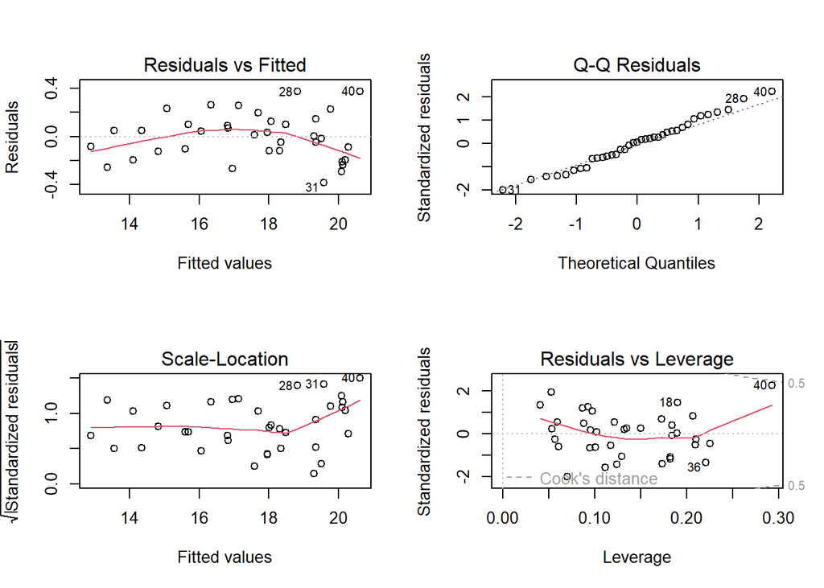

```r
par(mfrow = c(2,2))

plot(model_terbaik2)
```

```r
par(mfrow = c(1,1))
```

## Uji normaliras residual

```r
shapiro.test(residuals(model_terbaik2))
```

```
##
##  Shapiro-Wilk normality test
##
## data:  residuals(model_terbaik2)
## W = 0.98468, p-value = 0.8801
```

Berdasarkan uji Shapiro-Wilk diperoleh nilai W = 0,98468 dengan p-value = 0,8801. Karena p-value > 0,05, maka H₀ tidak ditolak, sehingga dapat disimpulkan bahwa residual model ARDL(3,0) berdistribusi normal. Jadi, asumsi normalitas residual pada model sudah terpenuhi.

## data aktual dan prediksi

```r
data_prediksi <- data.frame(
  Year = tail(data2$Year, length(fitted(model_terbaik2))),
  Aktual = tail(data2$Sales, length(fitted(model_terbaik2))),
  Prediksi = fitted(model_terbaik2)
)

data_prediksi
```

```
##    Year Aktual Prediksi
## 4  1978   12.8 12.88256
## 5  1979   13.1 13.35510
## 6  1980   13.6 13.55328
## 7  1981   13.9 14.09688
## 8  1982   14.4 14.35241
## 9  1983   14.7 14.82432
## 10 1984   15.3 15.06551
## 11 1985   15.5 15.60145
## 12 1986   15.8 15.69828
## 13 1987   16.1 16.05762
## 14 1988   16.6 16.33790
## 15 1989   16.9 16.81044
## 16 1990   16.7 16.96560
## 17 1991   16.9 16.83158
```

[output cut: 23 more lines]

## Plot Aktual VS Prediksi

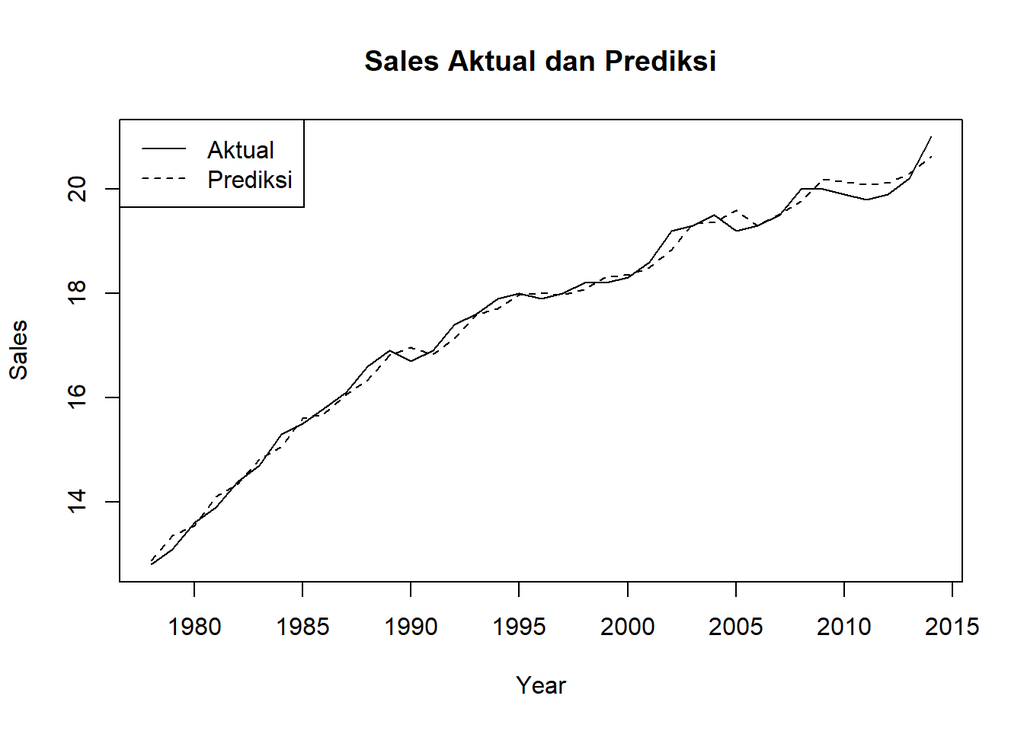

```r
plot(
  data_prediksi$Year,
  data_prediksi$Aktual,
  type = "l",
  xlab = "Year",
  ylab = "Sales",
  main = "Sales Aktual dan Prediksi"
)

lines(
  data_prediksi$Year,
  data_prediksi$Prediksi,
  lty = 2
)

legend(
  "topleft",
  legend = c("Aktual", "Prediksi"),
  lty = c(1,2)
)
```

Grafik Sales Aktual dan Prediksi menunjukkan bahwa garis prediksi (garis putus-putus) secara umum mengikuti pola garis aktual (garis penuh) dengan cukup dekat dari tahun ke tahun. Ini berarti model ARDL yang digunakan mampu menangkap pola perubahan nilai Sales dengan cukup baik. Perbedaan antara nilai aktual dan prediksi terlihat relatif kecil, sehingga hasil prediksi model dapat dikatakan cukup sesuai dengan data aktual.